# Лабораторная работа 3. Задание 2. Вариант 6

Дроздова Дарья, 5030102/80401

Файл ExpImp.RData содержит данные Росстата экспорт/импорт продукции по регионам России (млн долл. США). Нужно привести данные к формату tidydata. Отобразить значения суммарного экспорта и импорта по регионам в виде столбчатой диаграммы [сгруппировав значения по названию региона]. Экспорт и импорт обозначить разными цветами. Сделать график, на котором значения экспорта и импорта располагаются по разные стороны относительно оси x. Подписать величины экспорта и импорта.

Импортируем библиотеки

```r
library(ggplot2)
library(tidyr)
library(dplyr)
library(stringr)
```

Загружаем данные

```r
load("ExpImp.RData")
```

Функция для получения информации о суммарном экспорте и импорте по регионам

*Параметры*:

- data - исходный датафрейм

*Возвращает*: таблицу со столбцами Регион/СумИмпорт/СумЭкспорт

```r
create_data <- function(data) {
  data_district = data[grep('область$', data$Регион),]
  print(data_district)
  import = apply(data_district[grep('Импорт$', names(data_district))], 1, function(x) sum(as.numeric(str_replace_all(x, "-", "0"))))
  export = apply(data_district[grep('Экспорт$', names(data_district))], 1, function(x) sum(as.numeric(str_replace_all(x, "-", "0"))))
  data_district['СумИмпорт'] = import
  data_district['СумЭкспорт'] = export
  regions_import_export = data_district %>%
    select(1,14,15)

  return (regions_import_export)
}
```

Функция для построения графика

*Параметры*:

- data - tidydata с информацией для построения графика
- x_data - значения x
- y_data - значения y
- fill_data - значения для легенды
- title - заголовок графика
- x_title - подпись для оси х
- y_title - подпись для оси y
- fill_title - заголовок легенды

*Возвращает*: построенный график (подписи оси х повернуты на 90 градусов)

```r
build_graph <- function(data, x_data, y_data, fill_data, title, x_title, y_title, fill_title)  {
  return (ggplot(data, aes(x = x_data, y = y_data, fill = fill_data)) + geom_col(position = "dodge") +
            xlab(x_title) + ylab(y_title) + theme(axis.text.x = element_text(angle = 90)) +
            ggtitle(title) + scale_fill_discrete(name = fill_title))
}
```

Функция для построения графика с подписями

*Параметры*:

- data - tidydata с информацией для построения графика
- x_data - значения x
- y_data - значения y
- fill_data - значения для легенды
- label_data - значения для подписи
- title - заголовок графика
- x_title - подпись для оси х
- y_title - подпись для оси y
- fill_title - заголовок легенды

*Возвращает*: построенный график

```r
build_cord_graph <- function(data, x_data, y_data, fill_data, label_data, title, x_title, y_title, fill_title)  {
  ggplot(data, aes(x = x_data, y = y_data, group = fill_data)) +
    geom_col(aes(fill = fill_data)) +
    xlab(x_title) + ylab(y_title) +
    ggtitle(title) + scale_fill_discrete(name = fill_title) + coord_flip() +
    geom_text(aes(label = label_data), position = position_stack(vjust = 0.5))
}
```

Преобразование данных к формату tidydata

```r
regions = create_data(ExpImp)
```

```
## # A tibble: 47 x 13
##    Регион    ПродЭкспорт  ПродИмпорт  ТЭКЭкспорт ТЭКИмпорт ХимЭкспорт  ХимИмпорт
##    <chr>     <chr>        <chr>       <chr>      <chr>     <chr>           <dbl>
##  1 Белгород~ 221.9        613.799999~ 64.7       24.1      33.2999999~     243.
##  2 Брянская~ 28.5         650.299999~ 5          20.5      24.5             71.7
##  3 Владимир~ 177.9        454.3       0.9        16.7      87.7            419
##  4 Воронежс~ 373.7        181.9       38.9       38        976.9            84.9
##  5 Ивановск~ 3.1          105.5       0.1        0.1       40.7999999~      57.4
##  6 Калужска~ 20.9         184.6       14         57.9      54.9            370.
##  7 Костромс~ 0.7          6.8         0          -         19.3             10.2
##  8 Курская ~ 139.6        218.8       -          17.7      77.2            118.
##  9 Липецкая~ 161.8000000~ 301         49.8       107.9     6.8             218.
## 10 Московск~ 773.6        3829.9      1400.2     156.4     871.1          5632.
## # ... with 37 more rows, and 6 more variables: ДревЭкспорт <chr>,
## #   ДревИмпорт <dbl>, МетЭкспорт <chr>, МетИмпорт <dbl>, МашЭкспорт <chr>,
## #   МашИмпорт <dbl>
```

```r
regions_ti <- regions %>%
  pivot_longer(names_to = 'export_import',
               values_to = 'values',
               cols = -Регион)
```

Вызов функций

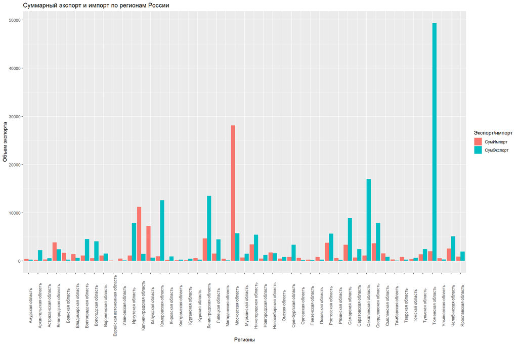

```r
export_import_regions = build_graph(regions_ti,
                             regions_ti$Регион,
                             regions_ti$values,
                             regions_ti$export_import,
                             'Суммарный экспорт и импорт по регионам России',
                             'Регионы',
                             'Объем экспорта',
                             'Экспорт/импорт')
export_import_regions
```

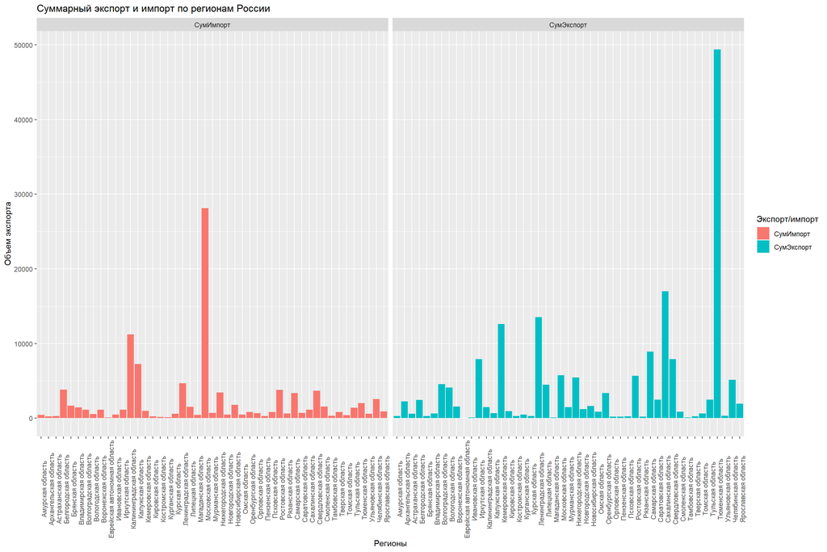

```r
export_import_regions + facet_grid(. ~ regions_ti$export_import)
```

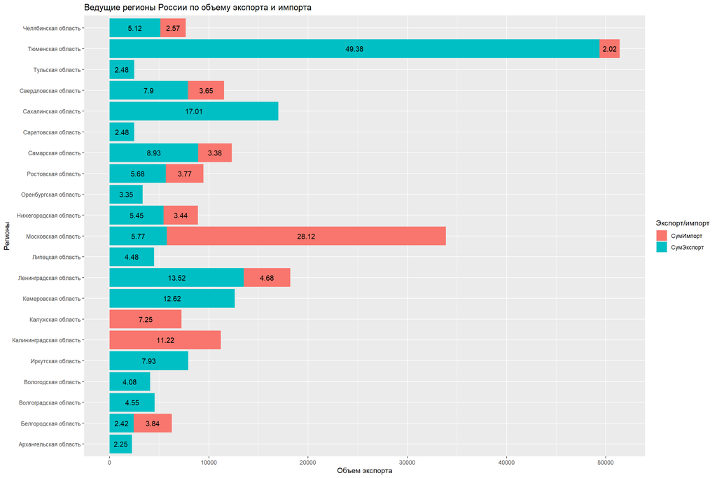

```r
main_regions = subset(regions_ti, regions_ti$values > 2000)
export_import_regions_main = build_cord_graph(main_regions,
                                              main_regions$Регион,
                                              main_regions$values,
                                              main_regions$export_import,
                                              round(main_regions$values/1000, 2),
                                              'Ведущие регионы России по объему экспорта и импорта',
                                              'Регионы',
                                              'Объем экспорта',
                                              'Экспорт/импорт')

export_import_regions_main
```